# Demo - Intereacting With MIDRC CT Scan Images

In this demo we will review how to import MIDRC imaging data, how to convert CT scan images from dicom (dcm) formats to png and jpeg formats, and how to view these CT scan images. This demo will also show how to extract file and patient metadata from the header of dicom (dcm) files.

### Import Data And Packages

Import the packages pydicom, pillow, and dicom_csv, as well as pandas, os and numpy. If any of these packages are not already installed to your workspace you can run one of the following:

- 'pip install < package >' in the workspace terminal
- '!pip install < package >' in a notebook cell

```python
!pip install pydicom -q
!pip install pillow -q
!pip install dicom-csv -q
```

```python
import pydicom
import numpy as np
from PIL import Image
import pandas as pd
import os
from dicom_csv import join_tree
import zipfile
```

Import data objects of CT scan images using the gen3SDK and unzip the files

```python
!gen3 --commons_url data.midrc.org drs-pull object dg.MD1R/52ed5c59-1910-499b-a80e-00329209e148
```

```
{"succeeded": ["dg.MD1R/52ed5c59-1910-499b-a80e-00329209e148"], "failed": []}
```

```python
zip_image_path = 'A840445/1.3.6.1.4.1.14519.5.2.1.99.1071.22152686345791690835528908062918/1.3.6.1.4.1.14519.5.2.1.99.1071.32717876047095240098568067022786.zip'

def unzip_all(zip_filepath, extract_to_dir):
    with zipfile.ZipFile(zip_filepath, 'r') as zip_ref:
        zip_ref.extractall(extract_to_dir)

extract_to_dir = 'COVID-19-NY-SBU'
unzip_all(zip_image_path, extract_to_dir)
```

All data objects are now stored under the folder 'COVID-19-NY-SBU'

### View Image

Read the dcm image using the relative file path.

```python
image_path = 'COVID-19-NY-SBU/1.3.6.1.4.1.14519.5.2.1.99.1071.32717876047095240098568067022786/1-105.dcm'
ds = pydicom.dcmread(image_path)
```

Get the pixel arrays for the image.

```python
new_image = ds.pixel_array.astype(float)
new_image
```

```
array([[-2048., -2048., -2048., ..., -2048., -2048., -2048.],
       [-2048., -2048., -2048., ..., -2048., -2048., -2048.],
       [-2048., -2048., -2048., ..., -2048., -2048., -2048.],
       ...,
       [-2048., -2048., -2048., ..., -2048., -2048., -2048.],
       [-2048., -2048., -2048., ..., -2048., -2048., -2048.],
       [-2048., -2048., -2048., ..., -2048., -2048., -2048.]])
```

Scale the image's pixel array and convert to a uint8 integer.

```python
scaled_image = (np.maximum(new_image, 0) / new_image.max()) * 255.0
scaled_image = np.uint8(scaled_image)
scaled_image
```

```
array([[0, 0, 0, ..., 0, 0, 0],
       [0, 0, 0, ..., 0, 0, 0],
       [0, 0, 0, ..., 0, 0, 0],
       ...,
       [0, 0, 0, ..., 0, 0, 0],
       [0, 0, 0, ..., 0, 0, 0],
       [0, 0, 0, ..., 0, 0, 0]], dtype=uint8)
```

Use the Image package to convert the image array and show the image.

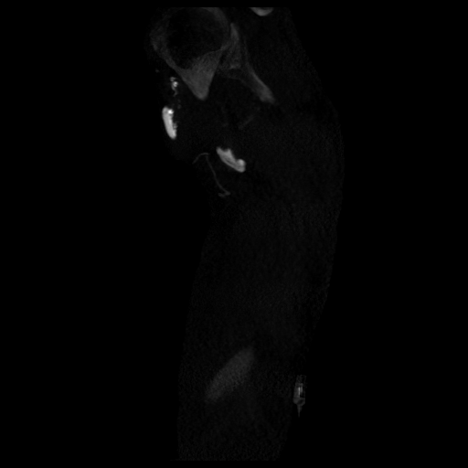

```python
final_image = Image.fromarray(scaled_image)
final_image.show()
```

### Convert Images

```python
def view_dicom_image(image_path):

    ds = pydicom.dcmread(image_path)

    new_image = ds.pixel_array.astype(float)

    scaled_image = np.uint8((np.maximum(new_image, 0) / new_image.max()) * 255.0)

    final_image = Image.fromarray(scaled_image)

    final_image.show()

def dcm_to_png(image_path):

    ds = pydicom.dcmread(image_path)

    new_image = ds.pixel_array.astype(float)

    scaled_image = np.uint8((np.maximum(new_image, 0) / new_image.max()) * 255.0)

    final_image = Image.fromarray(scaled_image)

    final_image.save(image_path.rsplit('/', 1)[1][:-3] + 'png')


def dcm_to_jpeg(image_path):

    ds = pydicom.dcmread(image_path)

    new_image = ds.pixel_array.astype(float)

    scaled_image = np.uint8((np.maximum(new_image, 0) / new_image.max()) * 255.0)

    final_image = Image.fromarray(scaled_image)

    final_image.save(image_path.rsplit('/', 1)[1][:-3] + 'jpg')
```

Convert dicom image to png and save.

```python
image_path = 'COVID-19-NY-SBU/1.3.6.1.4.1.14519.5.2.1.99.1071.32717876047095240098568067022786/1-103.dcm'
dcm_to_png(image_path)
```

Convert dicom image to jpg and save.

```python
image_path = 'COVID-19-NY-SBU/1.3.6.1.4.1.14519.5.2.1.99.1071.32717876047095240098568067022786/1-088.dcm'
dcm_to_jpeg(image_path)
```

Display a few dicom images.

[figure not shown]

```python
image_path = 'COVID-19-NY-SBU/1.3.6.1.4.1.14519.5.2.1.99.1071.32717876047095240098568067022786/1-001.dcm'
view_dicom_image(image_path)
```

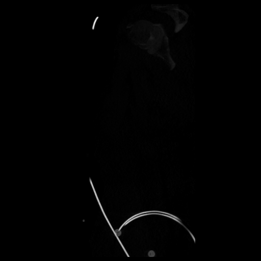

```python
image_path = 'COVID-19-NY-SBU/1.3.6.1.4.1.14519.5.2.1.99.1071.32717876047095240098568067022786/1-006.dcm'
view_dicom_image(image_path)
```

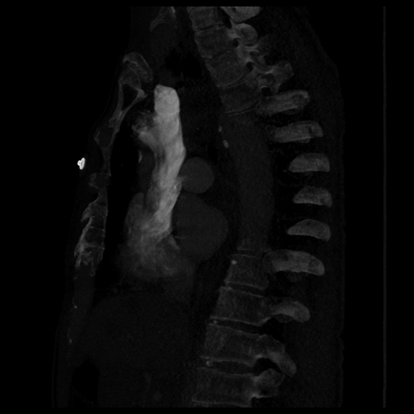

```python
image_path = 'COVID-19-NY-SBU/1.3.6.1.4.1.14519.5.2.1.99.1071.32717876047095240098568067022786/1-053.dcm'
view_dicom_image(image_path)
```

### Extract Metadata

The following function will extract the file and patient metadata from the header of each dicom (.dcm) file within a given folder and place the collected metadata into a pandas dataframe.

```python
def extract_metadata(base_folder):

    df = pd.DataFrame()
    file_folders = os.listdir(path = base_folder)

    for folder in file_folders:
            path = base_folder + '/' + folder
            meta = join_tree(path, verbose=2)
            df = pd.concat([df, meta])

    return df
```

```python
base_folder =  'COVID-19-NY-SBU'
metadata = extract_metadata(base_folder)
metadata
```

```
1-069.dcm: : 109it [00:01, 72.93it/s]
```

|  | AccessionNumber | AcquisitionDate | AcquisitionNumber | AcquisitionTime | AcquisitionType | BitsAllocated | BitsStored | BodyPartExamined | CTDIvol | ClinicalTrialTimePointDescription | ... | StudyTime | TableFeedPerRotation | TableHeight | TotalCollimationWidth | WindowCenter | WindowWidth | XRayTubeCurrent | NoError | PathToFolder | FileName |
| --- | --- | --- | --- | --- | --- | --- | --- | --- | --- | --- | --- | --- | --- | --- | --- | --- | --- | --- | --- | --- | --- |
| 0 |  | 19001223 | 5 | 003129.050 | SPIRAL | 16 | 16 | CHEST | 3.3 | Days offset from diagnosis | ... | 002814.000 | 55.5 | 55.0 | 40.0 | 70.0 | 500.0 | 102 | True | . | 1-088.dcm |
| 1 |  | 19001223 | 5 | 003129.050 | SPIRAL | 16 | 16 | CHEST | 3.3 | Days offset from diagnosis | ... | 002814.000 | 55.5 | 55.0 | 40.0 | 70.0 | 500.0 | 102 | True | . | 1-079.dcm |
| 2 |  | 19001223 | 5 | 003129.050 | SPIRAL | 16 | 16 | CHEST | 3.3 | Days offset from diagnosis | ... | 002814.000 | 55.5 | 55.0 | 40.0 | 70.0 | 500.0 | 102 | True | . | 1-097.dcm |
| 3 |  | 19001223 | 5 | 003129.050 | SPIRAL | 16 | 16 | CHEST | 3.3 | Days offset from diagnosis | ... | 002814.000 | 55.5 | 55.0 | 40.0 | 70.0 | 500.0 | 102 | True | . | 1-035.dcm |
| 4 |  | 19001223 | 5 | 003129.050 | SPIRAL | 16 | 16 | CHEST | 3.3 | Days offset from diagnosis | ... | 002814.000 | 55.5 | 55.0 | 40.0 | 70.0 | 500.0 | 102 | True | . | 1-071.dcm |
| ... | ... | ... | ... | ... | ... | ... | ... | ... | ... | ... | ... | ... | ... | ... | ... | ... | ... | ... | ... | ... | ... |
| 104 |  | 19001223 | 5 | 003129.050 | SPIRAL | 16 | 16 | CHEST | 3.3 | Days offset from diagnosis | ... | 002814.000 | 55.5 | 55.0 | 40.0 | 70.0 | 500.0 | 102 | True | . | 1-061.dcm |
| 105 |  | 19001223 | 5 | 003129.050 | SPIRAL | 16 | 16 | CHEST | 3.3 | Days offset from diagnosis | ... | 002814.000 | 55.5 | 55.0 | 40.0 | 70.0 | 500.0 | 102 | True | . | 1-078.dcm |
| 106 |  | 19001223 | 5 | 003129.050 | SPIRAL | 16 | 16 | CHEST | 3.3 | Days offset from diagnosis | ... | 002814.000 | 55.5 | 55.0 | 40.0 | 70.0 | 500.0 | 102 | True | . | 1-096.dcm |
| 107 |  | 19001223 | 5 | 003129.050 | SPIRAL | 16 | 16 | CHEST | 3.3 | Days offset from diagnosis | ... | 002814.000 | 55.5 | 55.0 | 40.0 | 70.0 | 500.0 | 102 | True | . | 1-087.dcm |
| 108 |  | 19001223 | 5 | 003129.050 | SPIRAL | 16 | 16 | CHEST | 3.3 | Days offset from diagnosis | ... | 002814.000 | 55.5 | 55.0 | 40.0 | 70.0 | 500.0 | 102 | True | . | 1-069.dcm |

109 rows × 103 columns

Included in this metadata are import pieces of file and patient data, such as the body part examined and the patient's sex

```python
metadata.columns[40:60]
```

```
Index(['KVP', 'LongitudinalTemporalInformationModified', 'Manufacturer',
       'ManufacturerModelName', 'Modality', 'PatientAge', 'PatientBirthDate',
       'PatientComments', 'PatientID', 'PatientIdentityRemoved', 'PatientName',
       'PatientPosition', 'PatientSex', 'PerformedProcedureStepStartDate',
       'PerformedProcedureStepStartTime', 'PhotometricInterpretation',
       'PixelRepresentation', 'PixelSpacing0', 'PixelSpacing1',
       'PositionReferenceIndicator'],
      dtype='object')
```

```python
metadata.BodyPartExamined
```

```
0      CHEST
1      CHEST
2      CHEST
3      CHEST
4      CHEST
       ...
104    CHEST
105    CHEST
106    CHEST
107    CHEST
108    CHEST
Name: BodyPartExamined, Length: 109, dtype: object
```

```python
metadata.PatientSex
```

```
0      M
1      M
2      M
3      M
4      M
      ..
104    M
105    M
106    M
107    M
108    M
Name: PatientSex, Length: 109, dtype: object
```